# 3. PCA Based Bands Selection

Preprocessed images will be used for selecting the most important bands out of all bands in given images.

Step to be followed are ..

- Preparation of eigen vectors and eigen values and save it into directory in .csv format
- Reload eigen statistics to decide maximum number of PCs to be selected for bands' selection
- Selection of three different sets of bands included in top N contributing bands with min_freq=2 where N = 10, 25, 50

## Load the hyperspeclib library

```python
import hyspeclib as hy
```

## Define all the paths

```python
##  Directory where all preprocessed images are kept
our_data_dir = 'anand/'
our_image_dir = our_data_dir+'Preprocessed_image/'

##  PCA Statistics Paths for saving and loading results
pca_stat_dir = our_data_dir+'pca_analysis_results/'
```

**pca_analysis** function automatically finds all the images in **our_image_dir** and **perform** method generate eigen values and eigen vectors for each image and store it.

```python
pca = hy.pca_analysis(image_directory_path=our_image_dir, save_dir = pca_stat_dir)
```

```
Total 2 images found in directory.
```

```python
pca.perform()
```

```
---------------- Computing PCA Statistics -------------------


Current image 1/2

Covariance.....  0.0Covariance.....  0.0Covariance.....done

Took 50.6499 seconds / 0.8442 min to run.


Current image 2/2

Covariance.....  0.0Covariance.....  0.0Covariance.....done

Took 29.7006 seconds / 0.4950 min to run.

Eigen Values and Eigen Vectors are saved successfully at : anand/pca_analysis_results/


-------------------------------------------------------------
```

## Perform analysis on PCA results

### Eigen values and cumulative percentage

We can observe that only first two PCs contained 99% infomation so further PCs will not be used for band selection

```python
pca.show_eigen_values(pca_result_directory=pca_stat_dir)
```

```
Eigen Values for partition : unprocessed_image_part_2_pca

   PC    E.V  Percentage  Cumulative Percent
0   1  3.176      88.785              88.785
1   2  0.383      10.702              99.486
2   3  0.008       0.210              99.696
3   4  0.004       0.109              99.806
4   5  0.002       0.042              99.848
5   6  0.001       0.033              99.881
6   7  0.001       0.023              99.904
7   8  0.001       0.014              99.918
8   9  0.000       0.012              99.930

Eigen Values for partition : unprocessed_image_part_1_pca

   PC    E.V  Percentage  Cumulative Percent
0   1  2.406      81.758              81.758
1   2  0.513      17.449              99.207
2   3  0.010       0.327              99.533
3   4  0.004       0.135              99.669
4   5  0.002       0.083              99.752
5   6  0.002       0.054              99.806
6   7  0.001       0.042              99.847
7   8  0.001       0.031              99.879
8   9  0.000       0.016              99.895
```

## Band Reduction usig PCA results

- **pca_result_directory** : path to the file which contains all the PCA output
- **top** : Number bands to be considered as of top contributing bands.
- **max_pc** : Maximum number of PCs to be considered for pca method. For e.g. max_pc = 2 means take mean of firat two pcs
- **min_frequency** : Minimum number of ocuurences of a band in top N contributing bands of all the images.

#### Bands in Top 10 contributing bands with min frequency of 2

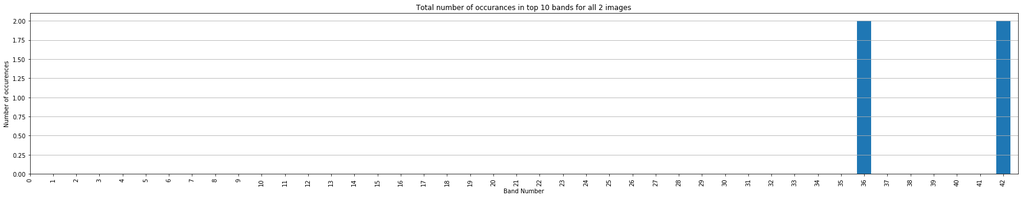

```python
pca.plot_band_frequncy(pca_result_directory=pca_stat_dir, top=10, max_pc=2, min_frequency=2)
```

```python
pca10 = pca.band_reduction(pca_result_directory=pca_stat_dir, top=10, max_pc=2, min_frequency=2)
print("Total bands : ",len(pca10))
print(pca10)
```

```
Total bands :  2
[36, 42]
```

#### Bands in Top 25 contributing bands with min frequency of 2

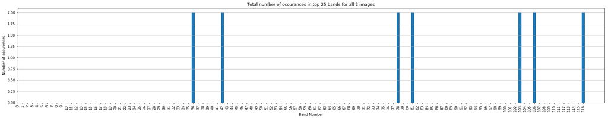

```python
pca.plot_band_frequncy(pca_result_directory=pca_stat_dir, top=25, max_pc=2, min_frequency=2)
```

```python
pca25 = pca.band_reduction(pca_result_directory=pca_stat_dir, top=25, max_pc=2, min_frequency=2)
print("Total bands : ",len(pca25))
print(pca25)
```

```
Total bands :  7
[36, 42, 78, 81, 103, 106, 116]
```

#### Bands in Top 50 contributing bands with min frequency of 2

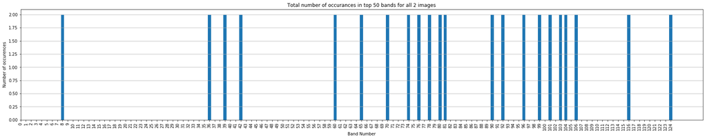

```python
pca.plot_band_frequncy(pca_result_directory=pca_stat_dir, top=50, max_pc=2, min_frequency=2)
```

```python
pca50 = pca.band_reduction(pca_result_directory=pca_stat_dir, top=50, max_pc=2, min_frequency=2)
print("Total bands : ",len(pca50))
print(pca50)
```

```
Total bands :  22
[8, 36, 39, 42, 60, 65, 70, 74, 76, 78, 80, 81, 90, 92, 96, 99, 101, 103, 104, 106, 116, 124]
```